# main

### Code for Black_Friday_Data_Hack_Project

#### Author: Rohan Surve

#### Date: April 23, 2019

### Import Libraries

```python
# Import libraries dealing with data processing, numerical computation
import pandas as pd
import numpy as np

# Other General Setup
import os
import sys

# Import local library modules
import src.build_features
import src.preprocess_data
import src.train_models
from src.make_dataset import make_dataset
from src.visualize_data import relationship_with_target
from src.blend_stacked_models import stack_models
from src.evaluate_models import evaluate_on_test

# to make this notebook's output stable across runs
np.random.seed(123)

# To plot pretty figures
%matplotlib inline
import matplotlib as mpl
import matplotlib.pyplot as plt
import seaborn as sns
mpl.rc('axes', labelsize=14)
mpl.rc('xtick', labelsize=12)
mpl.rc('ytick', labelsize=12)

# Ignore useless warnings
import warnings
warnings.filterwarnings(action="ignore", message="^internal gelsd")

PROJ_ROOT = os.getcwd()
print(os.path.abspath(PROJ_ROOT))
```

```
C:\Users\visha\Documents\GitHub\Black_Friday_Data_Hack\Black_Friday_Data_Hack
```

#### Following code lists all the dependancies used for this project (stored in requirements.txt file)

```python
# lists all the dependancies mentioned in requirements.txt file
print(open(os.path.join(PROJ_ROOT, 'requirements.txt')).read())
```

```
jupyter
ipython
notebook
numpy
pandas
matplotlib
seaborn
warnings
scikit-learn
xgboost
keras
```

## 1. Get The Data

```python
# Load the data
original_data_path = os.path.join(PROJ_ROOT,
                                  'data',
                                  'raw',
                                  'data.csv')

original_data = pd.read_csv(original_data_path)
original_data.head(3)
```

|  | User_ID | Product_ID | Gender | Age | Occupation | City_Category | Stay_In_Current_City_Years | Marital_Status | Product_Category_1 | Product_Category_2 | Product_Category_3 | Purchase |
| --- | --- | --- | --- | --- | --- | --- | --- | --- | --- | --- | --- | --- |
| 0 | 1000001 | P00069042 | F | 0-17 | 10 | A | 2 | 0 | 3 | NaN | NaN | 8370 |
| 1 | 1000001 | P00248942 | F | 0-17 | 10 | A | 2 | 0 | 1 | 6.0 | 14.0 | 15200 |
| 2 | 1000001 | P00087842 | F | 0-17 | 10 | A | 2 | 0 | 12 | NaN | NaN | 1422 |

### Take A Quick Look At The Data

```python
original_data.info()
```

```
<class 'pandas.core.frame.DataFrame'>
RangeIndex: 550068 entries, 0 to 550067
Data columns (total 12 columns):
User_ID                       550068 non-null int64
Product_ID                    550068 non-null object
Gender                        550068 non-null object
Age                           550068 non-null object
Occupation                    550068 non-null int64
City_Category                 550068 non-null object
Stay_In_Current_City_Years    550068 non-null object
Marital_Status                550068 non-null int64
Product_Category_1            550068 non-null int64
Product_Category_2            376430 non-null float64
Product_Category_3            166821 non-null float64
Purchase                      550068 non-null int64
dtypes: float64(2), int64(5), object(5)
memory usage: 50.4+ MB
```

```python
original_data.describe()
```

|  | User_ID | Occupation | Marital_Status | Product_Category_1 | Product_Category_2 | Product_Category_3 | Purchase |
| --- | --- | --- | --- | --- | --- | --- | --- |
| count | 5.500680e+05 | 550068.000000 | 550068.000000 | 550068.000000 | 376430.000000 | 166821.000000 | 550068.000000 |
| mean | 1.003029e+06 | 8.076707 | 0.409653 | 5.404270 | 9.842329 | 12.668243 | 9263.968713 |
| std | 1.727592e+03 | 6.522660 | 0.491770 | 3.936211 | 5.086590 | 4.125338 | 5023.065394 |
| min | 1.000001e+06 | 0.000000 | 0.000000 | 1.000000 | 2.000000 | 3.000000 | 12.000000 |
| 25% | 1.001516e+06 | 2.000000 | 0.000000 | 1.000000 | 5.000000 | 9.000000 | 5823.000000 |
| 50% | 1.003077e+06 | 7.000000 | 0.000000 | 5.000000 | 9.000000 | 14.000000 | 8047.000000 |
| 75% | 1.004478e+06 | 14.000000 | 1.000000 | 8.000000 | 15.000000 | 16.000000 | 12054.000000 |
| max | 1.006040e+06 | 20.000000 | 1.000000 | 20.000000 | 18.000000 | 18.000000 | 23961.000000 |

**General Observations About The Data**

```
1. Age is a categorical feature here. We can convert it to a numerical feature.
2. Occupation is a numerical feature here. Intuitively it should be categorical in nature.
3. Stay_In_Current_City_Years is a categorical feature. The value 4+ may be converted to 4
4. There are quite a few samples that have missing values for Product_Category_2 and a considerably high number of samples that have missing values for Product_Category_3
5. All the three Product Category columns have numerical features, whereas intuitively they should be categorical in nature.
6. Marital Status is a numerical feature, intuitively it should be categorical in nature.
7. User_ID and Product_ID are quite relevant features here. Both of them have multiple occurences in the dataset. While, Product_ID seems appropriately typed as categorical, User_ID (typed numeric) could be changed to a categorical type.
```

**Conclusively, there seems to be a data type mismatch in most of the features and we may have to change it to appropriate data type.**

##### This data set in its original form is quite large and hence considering the humble specs of my machine I would like to work on a sliced version of this data.

##### Inorder to do that let's use a local library function that generates a random slice of the data (size = 100k observations).

##### A copy of the file can be found at:

```
  * data
      * interim
```

##### The function definition can be found in:

```
  * src folder
      * make_dataset module
```

```python
# Using the function make_dataset, create an interim dataset and store it in the data folder
interim_data = make_dataset(original_data)
```

```python
# Check the shape of the interim dataset
interim_data.shape
```

```
(100000, 12)
```

## 2. Build Features

### Split The Data Into Train Set, Stacking Set and Test Set

```python
train_set, stacking_set, test_set = src.build_features.train_stack_test_split(interim_data, 0.7, 0.5)
```

```python
# Check the shapes of all three datasets
print(train_set.shape)
print(stacking_set.shape)
print(test_set.shape)
```

```
(70000, 12)
(15000, 12)
(15000, 12)
```

### Revise the features in all three datasets

```python
# Convert data types of features in train set, stacking set and test set

train_data_revised    = src.build_features.convert_data_types(train_set)
stacking_data_revised = src.build_features.convert_data_types(stacking_set)
test_data_revised     = src.build_features.convert_data_types(test_set)
```

[output not shown]

```python
# Check the revised dataset
train_data_revised.info()
```

```
<class 'pandas.core.frame.DataFrame'>
Int64Index: 70000 entries, 52308 to 15725
Data columns (total 12 columns):
User_ID                       70000 non-null object
Product_ID                    70000 non-null int64
Gender                        70000 non-null object
Age                           70000 non-null int64
Occupation                    70000 non-null category
City_Category                 70000 non-null object
Stay_In_Current_City_Years    70000 non-null int64
Marital_Status                70000 non-null category
Product_Category_1            70000 non-null category
Product_Category_2            47880 non-null category
Product_Category_3            21229 non-null category
Purchase                      70000 non-null int64
dtypes: category(5), int64(4), object(3)
memory usage: 4.6+ MB
```

```python
# Separate the features from the target for train set, stacking set and test set

train_features, train_target = src.build_features.separate_features_target(train_data_revised)
stacking_features, stacking_target = src.build_features.separate_features_target(stacking_data_revised)
test_features, test_target = src.build_features.separate_features_target(test_data_revised)
```

```python
# Prepare two separate lists, one of numerical features and other of categorical features (for train set)

train_num_feature_columns, train_cat_feature_columns = src.build_features.num_cat_feature_columns(train_data_revised)
stacking_num_feature_columns, stacking_cat_feature_columns = src.build_features.num_cat_feature_columns(stacking_data_revised)
test_num_feature_columns, test_cat_feature_columns = src.build_features.num_cat_feature_columns(test_data_revised)
```

## 3. Visualize The Data

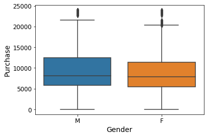

```python
# Explore how Purchase is related to customer gender
relationship_with_target(train_data_revised, 'Gender', PROJ_ROOT)
```

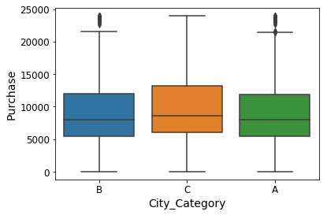

```python
# Explore the relationship between Product Sales and the city the customer lives in
relationship_with_target(train_data_revised, 'City_Category', PROJ_ROOT)
```

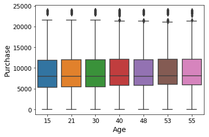

```python
# Explore how Product Sales (Amount) is related to the age of the customer
relationship_with_target(train_data_revised, 'Age', PROJ_ROOT)
```

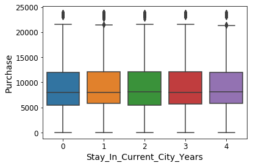

```python
# Explore the dependancy between the Product Sales (Amount) and the time duration
# for which a customer has stayed in the current city
relationship_with_target(train_data_revised, 'Stay_In_Current_City_Years', PROJ_ROOT)
```

### From the above exploratory data visualizations we see that the target variable `Purchase` is rather fairly uniformly distributed across different features

## 4. Pre-Process Data

#### Prepare Data For Machine Learning Algorithms

Let's create custom transformers for:

1. Handling Missing Values (SimpleImputer)
2. Feature Engineering (FunctionTransformer)
3. Convert All Categorical Data into One-Hot Encoders (OneHotEncoder)
4. Normalization of All Non-categorical Data (MinMaxScaler)

```python
train_prepared    = src.preprocess_data.transform_all_features(train_features, train_num_feature_columns, train_cat_feature_columns)
stacking_prepared = src.preprocess_data.transform_all_features(stacking_features, stacking_num_feature_columns, stacking_cat_feature_columns)
test_prepared     = src.preprocess_data.transform_all_features(test_features, test_num_feature_columns, test_cat_feature_columns)
```

## 5. Train Machine Learning Models

```python
# Train LASSO Regressor

lasso_model, lasso_score = src.train_models.train_lasso_reg(train_prepared, train_target)
```

```
Fitting 4 folds for each of 1 candidates, totalling 4 fits
```

```
[Parallel(n_jobs=-1)]: Using backend LokyBackend with 4 concurrent workers.
[Parallel(n_jobs=-1)]: Done   2 out of   4 | elapsed:  1.8min remaining:  1.8min
[Parallel(n_jobs=-1)]: Done   4 out of   4 | elapsed:  1.9min finished
```

```
LASSO Regression Model saved to disk
```

```python
# Train Random Forest Regressor

rnd_forest_model, rnd_forest_score = src.train_models.train_random_forest_reg(train_prepared, train_target)
```

```
[Parallel(n_jobs=-1)]: Using backend LokyBackend with 4 concurrent workers.
```

```
Fitting 4 folds for each of 1 candidates, totalling 4 fits
```

```
[Parallel(n_jobs=-1)]: Done   2 out of   4 | elapsed:   11.8s remaining:   11.8s
[Parallel(n_jobs=-1)]: Done   4 out of   4 | elapsed:   11.8s finished
```

```
Random Forest Model saved to disk
```

```python
# Train XGBoost Regressor

xgboost_model, xgboost_score = src.train_models.train_xgboost_reg(train_prepared, train_target)
```

```
Fitting 4 folds for each of 1 candidates, totalling 4 fits
```

```
[Parallel(n_jobs=-1)]: Using backend LokyBackend with 4 concurrent workers.
[Parallel(n_jobs=-1)]: Done   2 out of   4 | elapsed:  2.0min remaining:  2.0min
[Parallel(n_jobs=-1)]: Done   4 out of   4 | elapsed:  2.0min finished
```

```
XGBoost Model saved to disk
```

```python
# Train Deep Neural Network (Multi-layer Perceptron)

dnn_model, dnn_score = src.train_models.train_deep_neural_network(train_prepared, train_target)
```

```
DNN Model saved to disk
```

## 6. Stacking and Blending Models

```python
# Train and evaluate the Blender on Stacking set

blender_model, blender_score = stack_models(stacking_prepared,
                                            stacking_target,
                                            lasso_model,
                                            rnd_forest_model,
                                            xgboost_model,
                                            dnn_model)
```

## 7. Evaluate Best Model on Test Set

```python
# Create a table of all the models with their mean cross-validated scores

scoreboard = pd.DataFrame({'Model': ['LASSO Regressor', 'Random Forest Regressor', 'XGBoost Regressor', 'Deep Neural Network', 'Blender'],
                           'Score': [lasso_score, rnd_forest_score, xgboost_score, dnn_score, blender_score]})

print (scoreboard)
```

```
                     Model        Score
0          LASSO Regressor  2974.226616
1  Random Forest Regressor  3035.515064
2        XGBoost Regressor  2686.311677
3      Deep Neural Network  2912.012097
4                  Blender  2867.223313
```

### Clearly, XGBoost wins over others!!

```python
# Check the Performance of XGBoost on Test set

final_score = evaluate_on_test(xgboost_model, test_prepared, test_target)
```

```python
print('The final score of XGBoost Regressor on unseen data is {}'.format(np.round(final_score, 2)))
```

```
The final score of XGBoost Regressor on unseen data is 2709.96
```

#### Also, to compare the performance of Random Forest Regressor against Deep Neural Network on the (previously unseen) test data

```python
rnd_forest_score = evaluate_on_test(rnd_forest_model, test_prepared, test_target)
dnn_score = evaluate_on_test(dnn_model, test_prepared, test_target)

print('The score of Random Forest Regressor on unseen data is {}'.format(np.round(rnd_forest_score, 2)))
print('The score of Deep Neural Network on unseen data is {}'.format(np.round(dnn_score, 2)))
```

```
The score of Random Forest Regressor on unseen data is 3111.16
The score of Deep Neural Network on unseen data is 2985.07
```

#### Thus, after evaluating all the different models and their ensemble, we can conclude that XGBoost seems to have the lowest generalization error and hence better prediciting power.

### However, among Random Forest and Multi-Layer Perceptron, MLP seems to have lower generalization error and hence beats the Random Forest Regressor in terms of predicting power.